# Ch15 (2021) Worked Exercises

# 15.1 C&H IHD Incidence: inactive vs. active

## (i) log-lik($\theta$) fn. and its max.

Create the function log-likelihood($\theta$) in , plot it, and maximize it with respect to $\theta$ using `optimize`.

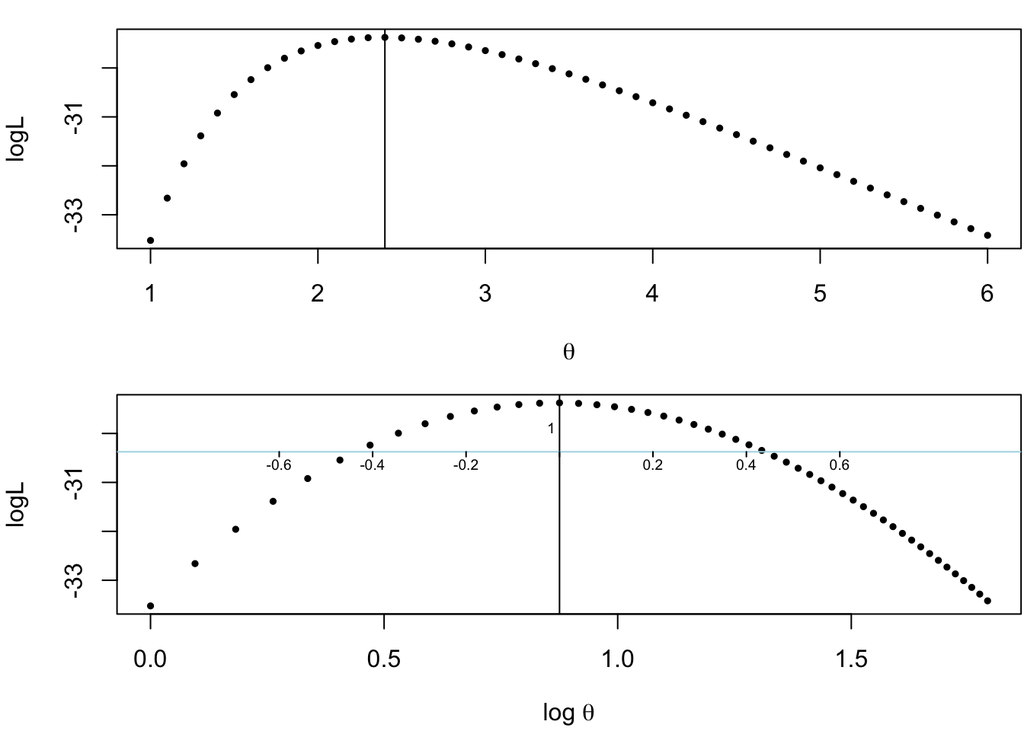

Fig. LogL(theta) vs. theta, and vs. log(theta). Q: how to VISUALLY estimate the CURVATURE?

```r
D1=c(2,12,14);
D=c(6,17,22);
X=c(1, 1, 1);
Y.ratio=c(311.9/607.9, 878.1/1272.1, 667.5/888.9);

loglik=function(theta)  sum(  D1*log(theta*Y.ratio)  -
 D*log(1+theta*Y.ratio)  )

THETA=seq(1,6,0.1)
logL = unlist(lapply(THETA,loglik))

par(mfrow=c(2,1),mar=c(4,4,1,0.1) )

plot(THETA,logL, xlab=expression(theta),pch=19,cex=0.5)

abline( v = THETA[logL==max(logL)] )

y = max(logL)-1



plot(log(THETA),logL, pch=19,cex=0.5,
     xlab=expression(paste("log ",theta)))
abline( v = log(THETA[logL==max(logL)]) )
abline( h = y, col="lightblue" )
mle = log(THETA[logL==max(logL)])
text(mle, y+1/2,
     "1", adj=c(1.5,0.5),cex=0.6)
for(th in seq(-0.6,0.6,0.2) ){
  segments(mle+th, y, mle+th, y-0.1)
  if(abs(th) > 0.01 ) text(mle+th, y-0.15, format(round(th,1),nsmall=1),
       adj=c(0.5,1), cex=0.6 )
}
```

```r
optimize(loglik,c(0,100),maximum=TRUE)
```

```
## $maximum
## [1] 2.386099
##
## $objective
## [1] -29.37461
```

## (ii) max [log-lik($\theta$) ] via `optim`

Unfortunately, `optimize` does not return the curvature (Hessian). But the `optim` function, which is recommended for 2- and higher dimensional searches, does. Instead of telling `optimize` the range within which to search, you pass the `optim` function a set of starting values for the parameter vector `par`.

So, trick the into maximizing a 1-parameter function, by including a `fake’ parameter that does not influence the log-likelihood. Use the returned Hessian to calculate the SE for $\hat{\theta}_{ML}.$

```r
loglik=function(par){
  theta = par[1]
  loglik= sum(  D1*log(theta*Y.ratio)  -
                D*log(1+theta*Y.ratio)  )
  return(loglik)
}

ml.fit = optim(c(1,0), loglik,hessian=TRUE,method="BFGS",
  control=list(fnscale=-1))

ml.fit
```

```
## $par
## [1] 2.386096 0.000000
##
## $value
## [1] -29.37461
##
## $counts
## function gradient
##       14        8
##
## $convergence
## [1] 0
##
## $message
## NULL
##
## $hessian
##           [,1] [,2]
## [1,] -1.850968    0
## [2,]  0.000000    0
```

```r
theta.hat = ml.fit$par[1]

SE = sqrt(-1/ml.fit$hessian[1,1])   # SE[theta-hat]

cat("theta.hat:", round(theta.hat,2), "; SE:",round(SE,2),
    "-- cf.  C&H p.143")
```

```
## theta.hat: 2.39 ; SE: 0.74 -- cf.  C&H p.143
```

Repeat, but focusing on log-likelihood($\beta$), where $\beta=\log[\theta],$ and compare your results with those of C&H.

**ANS**: One could (1) just examine the second graph above, (2) recode the `loglik` function so that `theta = exp(par[1])`, then pass a starting value of `log(theta)` or (3) apply the delta method to the SE obtained on the $\theta$ scale.

**approach (2) recode…**

```r
loglik=function(par){
  theta = exp(par[1])
  loglik= sum(  D1*log(theta*Y.ratio)  -
                D*log(1+theta*Y.ratio)  )
  return(loglik)
}

ml.fit = optim(c(0,0), loglik,hessian=TRUE,method="BFGS",
  control=list(fnscale=-1))

ml.fit
```

```
## $par
## [1] 0.8696587 0.0000000
##
## $value
## [1] -29.37461
##
## $counts
## function gradient
##       15        4
##
## $convergence
## [1] 0
##
## $message
## NULL
##
## $hessian
##          [,1] [,2]
## [1,] -10.5384    0
## [2,]   0.0000    0
```

```r
log.theta.hat = ml.fit$par[1]

SE = sqrt(-1/ml.fit$hessian[1,1])   # SE[theta-hat]
 cat("SE = sqrt(-1/ml.fit$hessian[1,1]) = sqrt[ 1 /",-ml.fit$hessian[1,1] ,"]" )
```

```
## SE = sqrt(-1/ml.fit$hessian[1,1]) = sqrt[ 1 / 10.5384 ]
```

```r
cat("log.theta.hat:", round(log.theta.hat,2), "; SE:",round(SE,2) )
```

```
## log.theta.hat: 0.87 ; SE: 0.31
```

## max[log-lik] with explicit binomial contributions

```r
D1 = c(2,12,14)
D  = c(6,17,22)
D0 = D - D1

Y.ratio=c(311.9/607.9, 878.1/1272.1, 667.5/888.9)

BinomialLoglik=function(par){
  theta = exp( par[1] )
  ODDS = theta*Y.ratio
  # P = prob.case.was.exposed =
  P = ODDS/(ODDS+1)
  logL = sum(log( dbinom(D1,  D,   P ) ) )

  return(logL)
}

BinomialLoglik(c(0.85,0))
```

```
## [1] -5.26288
```

```r
BinomialLoglik(c(0.869,0))
```

```
## [1] -5.260842
```

```r
BinomialLoglik(c(0.90,0))
```

```
## [1] -5.265679
```

```r
ml.fit = optim(c(0,0),
               BinomialLoglik,hessian=TRUE,method="BFGS",
  control=list(fnscale=-1))

ml.fit
```

```
## $par
## [1] 0.8696588 0.0000000
##
## $value
## [1] -5.26084
##
## $counts
## function gradient
##       13        5
##
## $convergence
## [1] 0
##
## $message
## NULL
##
## $hessian
##          [,1] [,2]
## [1,] -10.5384    0
## [2,]   0.0000    0
```

## (iii) how much confounding?

Did C&H pick a good example where a confounding factor (here age), if ignored, would lead to a very different (and very wrong) answer? Answer by calculating $\hat{\theta}_{ML}$ for the data (as in Chapter 13, i.e. before they segregated the data by age). Note the difference between aggregating across strata, and aggregating (by summing likelihoods, or by some other weighting) across strata.

**ANS**: As per C&H’s answer on page 131, to their exercise 13.1, the crude MLE is $\hat{\theta}=2.48$, so the correction for the age imbalance is minimal.

## (iv) GLM: 1-par. CONDN’L

Instead of explicitly defining and maximizing the conditional/profile likelihood, which simplifies in this example to a 1-parameter binomial-based likelihood, obtain $\hat{\theta}_{ML}$ using a `GLM`, for example, in `R`, and verify that fitting this `GLM` leads to the same $\log \hat{\theta}$ = 0.8697 and SE = 0.3080 that C&H report at the bottom/top of page 142/143.

```r
D1=c(2,12,14); D=c(6,17,22); X=c(1,1,1);
Y.ratio=c(311.9/607.9, 878.1/1272.1, 667.5/888.9);

fit=glm(cbind(D1,D-D1)~-1+X,family=binomial,
        offset=log(Y.ratio))
summary(fit)
```

```
##
## Call:
## glm(formula = cbind(D1, D - D1) ~ -1 + X, family = binomial,
##     offset = log(Y.ratio))
##
## Deviance Residuals:
##        1         2         3
## -1.07031   0.72413  -0.05319
##
## Coefficients:
##   Estimate Std. Error z value Pr(>|z|)
## X   0.8697     0.3080   2.823  0.00476 **
## ---
## Signif. codes:  0 '***' 0.001 '**' 0.01 '*' 0.05 '.' 0.1 ' ' 1
##
## (Dispersion parameter for binomial family taken to be 1)
##
##     Null deviance: 9.9717  on 3  degrees of freedom
## Residual deviance: 1.6727  on 2  degrees of freedom
## AIC: 12.522
##
## Number of Fisher Scoring iterations: 3
```

```r
beta.hat=log.theta.hat=fit$coefficients;
theta.hat=exp(log.theta.hat)
Var.beta.hat = summary(fit)$cov.unscaled[1,1]

cat("Beta.hat", round(beta.hat,2), "; theta.hat", round(theta.hat,2),
    "; Var.beta.hat", round(Var.beta.hat,4))
```

```
## Beta.hat 0.87 ; theta.hat 2.39 ; Var.beta.hat 0.0949
```

## (v) GLM 4-par. UNCONDN’L

What would happen if you used the same p.h. model but fitted all 4 parameters in an *un*conditional approach? Use this code to see: you have 6 Poisson observations, the link is a log link, and the 6 log(y)’s serve as offsets.

`D.all6 = c(D1,D-D1) ;Index.category=c(1,1,1,0,0,0)`  
`Y.all6=c(311.9,878.1,667.5, 607.9,1272.1,888.9)`  
`Stratum=c(1:3,1:3)`

`Poisson.fit=`  
`glm(D.all6 ~ as.factor(Stratum) + Index.category ,`  
family=poisson,offset=log(Y.all6))summary(Poisson.fit)exp(Poisson.fit$coefficients)`

**ANS**

```r
D.all6 = c(D1,D-D1) ;Index.category=c(1,1,1,0,0,0)
Y.all6=c(311.9,878.1,667.5, 607.9,1272.1,888.9)
Stratum=c(1:3,1:3)

Poisson.fit = glm(D.all6 ~ as.factor(Stratum) + Index.category ,
                  family=poisson,offset=log(Y.all6))
summary(Poisson.fit)
```

```
##
## Call:
## glm(formula = D.all6 ~ as.factor(Stratum) + Index.category, family = poisson,
##     offset = log(Y.all6))
##
## Deviance Residuals:
##        1         2         3         4         5         6
## -0.77385   0.42800  -0.03191   0.73940  -0.58410   0.04255
##
## Coefficients:
##                     Estimate Std. Error z value Pr(>|z|)
## (Intercept)          -5.4177     0.4421 -12.256  < 2e-16 ***
## as.factor(Stratum)2   0.1290     0.4754   0.271  0.78609
## as.factor(Stratum)3   0.6920     0.4614   1.500  0.13366
## Index.category        0.8697     0.3080   2.823  0.00476 **
## ---
## Signif. codes:  0 '***' 0.001 '**' 0.01 '*' 0.05 '.' 0.1 ' ' 1
##
## (Dispersion parameter for poisson family taken to be 1)
##
##     Null deviance: 14.5780  on 5  degrees of freedom
## Residual deviance:  1.6727  on 2  degrees of freedom
## AIC: 31.796
##
## Number of Fisher Scoring iterations: 4
```

```r
round(exp(Poisson.fit$coefficients),4)
```

```
##         (Intercept) as.factor(Stratum)2 as.factor(Stratum)3      Index.category
##              0.0044              1.1377              1.9978              2.3861
```

Comment on your results.

**ANS**

The 4 fitted coefficients allow us to show 6 fitted rates (left), and therefore, 6 fitted numbers of cases(right), along with observed ninbers of cases (note that order of columns is same as in C&H)

```r
beta = Poisson.fit$coefficients
log.rates.in.unexposed = c(beta[1], beta[1]+beta[2], beta[1]+beta[3])
log.rates.in.exposed   = log.rates.in.unexposed + beta[4]
LP = c(log.rates.in.exposed,log.rates.in.unexposed)
fitted.Rates = 1000*exp(LP)
fitted.Rates = matrix( fitted.Rates, 3,2)
cat("Fitted Rates")
```

```
## Fitted Rates
```

```r
print(round(fitted.Rates,2))
```

```
##       [,1] [,2]
## [1,] 10.59 4.44
## [2,] 12.05 5.05
## [3,] 21.15 8.87
```

```r
fitted.Cases = fitted.Rates *  matrix(Y.all6,3,2)/1000
cat("Fitted Numbers of Cases")
```

```
## Fitted Numbers of Cases
```

```r
print( round(fitted.Cases,1) )
```

```
##      [,1] [,2]
## [1,]  3.3  2.7
## [2,] 10.6  6.4
## [3,] 14.1  7.9
```

```r
cat("Observed Numbers of Cases")
```

```
## Observed Numbers of Cases
```

```r
print( matrix(D.all6,3,2) )
```

```
##      [,1] [,2]
## [1,]    2    4
## [2,]   12    5
## [3,]   14    8
```

```r
cat("Observed minus Fitted Numbers of Cases")
```

```
## Observed minus Fitted Numbers of Cases
```

```r
print( round(matrix(D.all6,3,2) - fitted.Cases,1)  )
```

```
##      [,1] [,2]
## [1,] -1.3  1.3
## [2,]  1.4 -1.4
## [3,] -0.1  0.1
```

## (vi) $\hat{\theta}_{CN'L}=\hat{\theta}_{UNCNDN'L}$?

Remember to ask next term’s MATH523 (GLM) teacher to explain to you why you get the (dis)agreement you get between the conditional and unconditional approaches to Poisson data.

Also ask the teacher (or try it for yourself) whether you would you get the same odds ratio if you fitted an unconditional (2-binomial) model and the conditional (non-central hypergeometric) model to the frequencies a=3, b=2, c=1, d=1. Hint: see page 126 in The-Analysis-Of-Case-Control-Studies-1980, by Breslow and Day.

`***********************************************************************`

# 15.6 BNT162b2 EFFECTIVENESS against Death from Delta Variant

In order to apply the methods in C&H’s Ch. 15 to the data given above …

## (i) The PH model

Summarize the key points they make in Section 15.1.

## (ii) From 6 parameters to 4 to 1

In the first paragraph of section 15.2, what are the ‘four parameters, which are free to take any positive value’? (see p. 1 of JH’s Notes)

## (iii) 1-para LogLik($\theta$)

Both the profile and conditional log-likelihoods eliminate three of these, and leave us with the 1-parameter log-likelihood given in line 8 of page 144. That single parameter $\theta$ is hidden inside each of the 3 $\Omega$’s.

Code this logLik as an R function of $\log \theta$ and plot it, just as C&H do in Figure 15.1. By the way, take note of the word **common** in their label on their x-axis. Also take note of how symmetric it is: the more symmetric, the more accurate is the z-based CI for $\log \theta$.

**ANS**

Fom C&H page 144

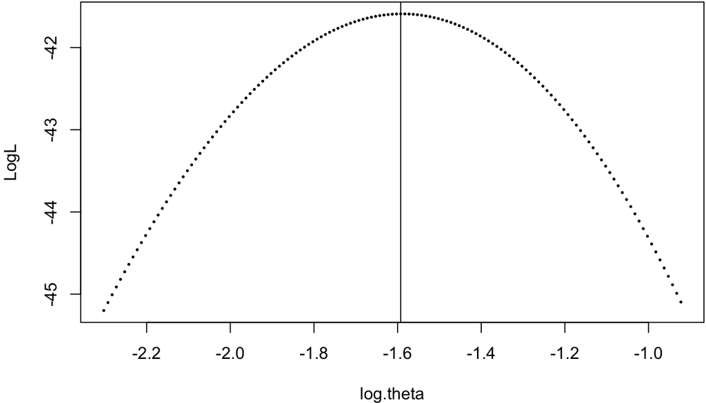

Fig. LogL vs. log(theta)

```r
D1      = c(   0,    2,    24)
D       = c(17+0, 33+2, 24+24)

Y.ratio = c(567.3/8669.5, 629.8/1230.3,  351.0/81.4 )

loglik=function(par){
  theta = exp(par[1])
  Omega = theta * Y.ratio
  loglik= sum(  D1*log(Omega)  -
                D*log(1+Omega)  )
  return(loglik)
}

log.theta = seq(log(1/10),log(2/5),0.01)
LogL = unlist(lapply(log.theta,loglik))

par(mfrow=c(1,1),mar=c(4,4,0.1,0.1) )

plot(log.theta,LogL,cex=0.25,pch=19)
abline(v=log.theta[LogL==max(LogL)])
```

## (iv) fitted via `optim`

Maximize it using the optimize (or better still the optim) function. (The latter also gives you the curvature, and thus the SE of the fitted value.)

**ANS**

```r
ml.fit = optim(c(1,0), loglik,hessian=TRUE,method="BFGS",
  control=list(fnscale=-1))

ml.fit
```

```
## $par
## [1] -1.589423  0.000000
##
## $value
## [1] -41.59007
##
## $counts
## function gradient
##       15        5
##
## $convergence
## [1] 0
##
## $message
## NULL
##
## $hessian
##           [,1] [,2]
## [1,] -15.16903    0
## [2,]   0.00000    0
```

```r
log.theta.hat = ml.fit$par[1]

theta.hat = exp(log.theta.hat)

SE = sqrt(-1/ml.fit$hessian[1,1])   # SE[theta-hat]

cat("theta.hat:", format(round(theta.hat,2),nsmall=2), "; SE[log(thata.hat)]:",round(SE,2))
```

```
## theta.hat: 0.20 ; SE[log(thata.hat)]: 0.26
```

```r
MME = exp( qnorm(c(0.975, 0.50, 0.025)) * SE)
VE = 100*(1-theta.hat*MME)
cat("(2.5, 50, 97.5) VE% :", round(VE))
```

```
## (2.5, 50, 97.5) VE% : 66 80 88
```

## (v) fitted via GLM

Instead of ‘rolling your own’, use a 1-parameter GLM (binomial) model, similar to that shown in JH’s Notes on section 15.2.

**ANS**

```r
D1 =c( 0, 2, 24)
D    = c(17+0, 33+2, 24+24)
O    = log( c(567.3/8669.5, 629.8/1230.3,  351.0/81.4 ) )

fit = glm( cbind(D1,D-D1) ~ 1 + offset(O),
               family = binomial)
summary(fit)
```

```
##
## Call:
## glm(formula = cbind(D1, D - D1) ~ 1 + offset(O), family = binomial)
##
## Deviance Residuals:
##       1        2        3
## -0.6715  -0.8113   0.4433
##
## Coefficients:
##             Estimate Std. Error z value Pr(>|z|)
## (Intercept)  -1.5894     0.2568   -6.19    6e-10 ***
## ---
## Signif. codes:  0 '***' 0.001 '**' 0.01 '*' 0.05 '.' 0.1 ' ' 1
##
## (Dispersion parameter for binomial family taken to be 1)
##
##     Null deviance: 1.3057  on 2  degrees of freedom
## Residual deviance: 1.3057  on 2  degrees of freedom
## AIC: 10.194
##
## Number of Fisher Scoring iterations: 3
```

```r
theta.hat = round(exp(fit$coefficients),2)

library(MASS)
UL.log.theta = confint(fit) # needs MASS to be installed
VE = 100*(1-theta.hat)


cat("theta.hat [HR.hat]:",format(round(theta.hat,2),nsmall=2))
```

```
## theta.hat [HR.hat]: 0.20
```

```r
cat("VE: point est:", format(round(VE)),
    "%;  95%CI:",
    format(round(100*(1-exp(UL.log.theta[1])))  ),
    "%  to",
    format(round(100*(1-exp(UL.log.theta[2])))  ),
    "%")
```

```
## VE: point est: 80 %;  95%CI: 88 %  to 67 %
```

## (vi) 4-para’s: Fitted Values

Present the fitted (unconditional) model in the 2 formats given at the beginning of JH’s Notes on Ch 15.1.14

**ANS**

6 Poisson observations, the link is a log link, and the 6 log(Y)’s serve as offsets.

```r
D.all6 = c(D1,D-D1)
Index.category=c(1,1,1,0,0,0)
Y.all6=c(567.3, 629.8, 351.0,  8669.5,1230.3, 81.4 )
Stratum=c(1:3,1:3)

Poisson.fit =
glm(D.all6 ~ as.factor(Stratum) + Index.category ,
             family=poisson,offset=log(Y.all6))

summary(Poisson.fit)
```

```
##
## Call:
## glm(formula = D.all6 ~ as.factor(Stratum) + Index.category, family = poisson,
##     offset = log(Y.all6))
##
## Deviance Residuals:
##        1         2         3         4         5         6
## -0.66931  -0.77772   0.32007   0.05457   0.23114  -0.30670
##
## Coefficients:
##                     Estimate Std. Error z value Pr(>|z|)
## (Intercept)          -6.2476     0.2426 -25.757   <2e-16 ***
## as.factor(Stratum)2   2.5886     0.2964   8.735   <2e-16 ***
## as.factor(Stratum)3   5.0883     0.3054  16.658   <2e-16 ***
## Index.category       -1.5894     0.2568  -6.190    6e-10 ***
## ---
## Signif. codes:  0 '***' 0.001 '**' 0.01 '*' 0.05 '.' 0.1 ' ' 1
##
## (Dispersion parameter for poisson family taken to be 1)
##
##     Null deviance: 288.3024  on 5  degrees of freedom
## Residual deviance:   1.3057  on 2  degrees of freedom
## AIC: 31.986
##
## Number of Fisher Scoring iterations: 4
```

```r
exp(Poisson.fit$coefficients)
```

```
##         (Intercept) as.factor(Stratum)2 as.factor(Stratum)3      Index.category
##        1.935061e-03        1.331116e+01        1.621066e+02        2.040433e-01
```

```r
beta = Poisson.fit$coefficients

log.rates.in.unexposed = c(beta[1], beta[1]+beta[2], beta[1]+beta[3])
log.rates.in.exposed   = log.rates.in.unexposed + beta[4]
LP = c(log.rates.in.exposed,log.rates.in.unexposed)
fitted.Rates = 100*exp(LP)
fitted.Rates = matrix( fitted.Rates, 3,2)
cat("Fitted Rates (Deaths per 100000 PY")
```

```
## Fitted Rates (Deaths per 100000 PY
```

```r
print(round(fitted.Rates,2))
```

```
##      [,1]  [,2]
## [1,] 0.04  0.19
## [2,] 0.53  2.58
## [3,] 6.40 31.37
```

```r
fitted.Cases = fitted.Rates *  matrix(Y.all6,3,2) /100
cat("Fitted Numbers of Cases")
```

```
## Fitted Numbers of Cases
```

```r
print( round(fitted.Cases,1) )
```

```
##      [,1] [,2]
## [1,]  0.2 16.8
## [2,]  3.3 31.7
## [3,] 22.5 25.5
```

```r
cat("Observed Numbers of Cases")
```

```
## Observed Numbers of Cases
```

```r
print( matrix(D.all6,3,2) )
```

```
##      [,1] [,2]
## [1,]    0   17
## [2,]    2   33
## [3,]   24   24
```

```r
cat("Observed minus Fitted Numbers of Cases")
```

```
## Observed minus Fitted Numbers of Cases
```

```r
print( round(matrix(D.all6,3,2) - fitted.Cases,1)  )
```

```
##      [,1] [,2]
## [1,] -0.2  0.2
## [2,] -1.3  1.3
## [3,]  1.5 -1.5
```

## (viii)

Compare the fitted ratio with the ratio of the standardized rates you calculated last week. Which method would you prefer to explain to a journalist? What is gained by the modelling approach, and at what ‘cost’ ?

**ANS**

## (ix)

Summarize the new elements learned during this exercise.

# 15.7 Estimating Eq.: ‘almost-MLE’ (Mantel-Haenszel)

## (i)

Follow the iterative re-weighting scheme 1.2.3. described by C&H on the bottom of page 144 to the data in Exercise 15.6.

**ANS**

```r
D0 =   D - D1
PY1 = c(567.3, 629.8, 351.0)
PY0 = c(8669.5,1230.3, 81.4)

PY = PY0 + PY1

theta.hat = 1

for(iteration in 1:5){
  if(iteration==1) print(noquote("Iteration theta.hat"))
  W = 1/(PY0 + theta.hat*PY1)
  theta.hat = sum(W * D1 * PY0) / sum(W * D0 * PY1)
  print( noquote( paste("    ", iteration, "   " , round(theta.hat,5) )  ) )
}
```

```
## [1] Iteration theta.hat
## [1]      1     0.18426
## [1]      2     0.20486
## [1]      3     0.20401
## [1]      4     0.20404
## [1]      5     0.20404
```

## (ii)

How many iterations does it take to get the same ‘to-2-decimal-places’ estimate of $\theta$?

**ANS** see above.

## (iii)

How good a job does the 1-step Mantel-Haenszel estimator do?

**ANS** Not quite as well as in C&H’s example, becuse in this application, $\theta$ is much further away from the null (1). But is still only ‘off’ by `20/204` = 10 %.

## (iv)

How good a job does the ‘approximate interval around the Mantel- Haenszel estimate’ do? (See lines 5-10 of page 146).

**ANS**

`Q = sum(D1 * PY0 / PY)` = 5.84 ; `R = sum(D0 * PY1 / PY)` = 31.7 ; `RR.MH = Q/R` = 0.18

`V = sum( D * (PY1/PY)*(PY0/PY` = 16.15

`S = sqrt(V/(Q*R))` = 0.30 overestimates the SE[log theta.hat] a little. In direct ML fitting, in part (iv) above, SE was 0.26.